# **Video Games Analysis**

**EDA: Exploratory Data Analysis**

- we analyze the data
- clean the data
- visualize the data to derive inferences

```python
#import the libraries

import pandas as pd
import numpy as np
import matplotlib.pyplot as plt
import seaborn as sns
```

```python
#read the data

df = pd.read_csv('vgsales.csv')
```

```python
df.tail(10)
```

|  | Rank | Name | Platform | Year | Genre | Publisher | NA_Sales | EU_Sales | JP_Sales | Other_Sales | Global_Sales |
| --- | --- | --- | --- | --- | --- | --- | --- | --- | --- | --- | --- |
| 16588 | 16591 | Mega Brain Boost | DS | 2008.0 | Puzzle | Majesco Entertainment | 0.01 | 0.00 | 0.00 | 0.0 | 0.01 |
| 16589 | 16592 | Chou Ezaru wa Akai Hana: Koi wa Tsuki ni Shiru... | PSV | 2016.0 | Action | dramatic create | 0.00 | 0.00 | 0.01 | 0.0 | 0.01 |
| 16590 | 16593 | Eiyuu Densetsu: Sora no Kiseki Material Collec... | PSP | 2007.0 | Role-Playing | Falcom Corporation | 0.00 | 0.00 | 0.01 | 0.0 | 0.01 |
| 16591 | 16594 | Myst IV: Revelation | PC | 2004.0 | Adventure | Ubisoft | 0.01 | 0.00 | 0.00 | 0.0 | 0.01 |
| 16592 | 16595 | Plushees | DS | 2008.0 | Simulation | Destineer | 0.01 | 0.00 | 0.00 | 0.0 | 0.01 |
| 16593 | 16596 | Woody Woodpecker in Crazy Castle 5 | GBA | 2002.0 | Platform | Kemco | 0.01 | 0.00 | 0.00 | 0.0 | 0.01 |
| 16594 | 16597 | Men in Black II: Alien Escape | GC | 2003.0 | Shooter | Infogrames | 0.01 | 0.00 | 0.00 | 0.0 | 0.01 |
| 16595 | 16598 | SCORE International Baja 1000: The Official Game | PS2 | 2008.0 | Racing | Activision | 0.00 | 0.00 | 0.00 | 0.0 | 0.01 |
| 16596 | 16599 | Know How 2 | DS | 2010.0 | Puzzle | 7G//AMES | 0.00 | 0.01 | 0.00 | 0.0 | 0.01 |
| 16597 | 16600 | Spirits & Spells | GBA | 2003.0 | Platform | Wanadoo | 0.01 | 0.00 | 0.00 | 0.0 | 0.01 |

**How much data do we have?**

```python
df.shape
```

```
(16598, 11)
```

```python
df.info()
```

```
<class 'pandas.core.frame.DataFrame'>
RangeIndex: 16598 entries, 0 to 16597
Data columns (total 11 columns):
 #   Column        Non-Null Count  Dtype
---  ------        --------------  -----
 0   Rank          16598 non-null  int64
 1   Name          16598 non-null  object
 2   Platform      16598 non-null  object
 3   Year          16327 non-null  float64
 4   Genre         16598 non-null  object
 5   Publisher     16540 non-null  object
 6   NA_Sales      16598 non-null  float64
 7   EU_Sales      16598 non-null  float64
 8   JP_Sales      16598 non-null  float64
 9   Other_Sales   16598 non-null  float64
 10  Global_Sales  16598 non-null  float64
dtypes: float64(6), int64(1), object(4)
memory usage: 1.4+ MB
```

```python
df.columns
```

```
Index(['Rank', 'Name', 'Platform', 'Year', 'Genre', 'Publisher', 'NA_Sales',
       'EU_Sales', 'JP_Sales', 'Other_Sales', 'Global_Sales'],
      dtype='object')
```

**Description of Data**

1. '**Rank**' : Position of game in the dataset
2. '**Name**' : Name of the game
3. '**Platform**' : Platform where game was initially launched
4. '**Year**' : Year when game was launched
5. '**Genre**' : Type of the game
6. '**Publisher**' : Who published the game
7. '**NA_Sales**' : Sales of the game in North America
8. '**EU_Sales**' : Sales of the game in Europe
9. '**JP_Sales**' : Sales of the game in Japan
10. '**Other_Sales**' : Sales in other countries
11. '**Global_Sales**' : Sales on global scale(together)

**Statistical description of Data**

```python
df.describe().T

#.T: convert rows to columns and vice-versa (Transpose)
```

|  | count | mean | std | min | 25% | 50% | 75% | max |
| --- | --- | --- | --- | --- | --- | --- | --- | --- |
| Rank | 16598.0 | 8300.605254 | 4791.853933 | 1.00 | 4151.25 | 8300.50 | 12449.75 | 16600.00 |
| Year | 16327.0 | 2006.406443 | 5.828981 | 1980.00 | 2003.00 | 2007.00 | 2010.00 | 2020.00 |
| NA_Sales | 16598.0 | 0.264667 | 0.816683 | 0.00 | 0.00 | 0.08 | 0.24 | 41.49 |
| EU_Sales | 16598.0 | 0.146652 | 0.505351 | 0.00 | 0.00 | 0.02 | 0.11 | 29.02 |
| JP_Sales | 16598.0 | 0.077782 | 0.309291 | 0.00 | 0.00 | 0.00 | 0.04 | 10.22 |
| Other_Sales | 16598.0 | 0.048063 | 0.188588 | 0.00 | 0.00 | 0.01 | 0.04 | 10.57 |
| Global_Sales | 16598.0 | 0.537441 | 1.555028 | 0.01 | 0.06 | 0.17 | 0.47 | 82.74 |

```python
df.describe(include='O')
```

|  | Name | Platform | Genre | Publisher |
| --- | --- | --- | --- | --- |
| count | 16598 | 16598 | 16598 | 16540 |
| unique | 11493 | 31 | 12 | 578 |
| top | Need for Speed: Most Wanted | DS | Action | Electronic Arts |
| freq | 12 | 2163 | 3316 | 1351 |

**Missing value Analysis**

1. if number of rows that contain null values < 30% of entire dataset :

`drop the null rows` 2. if number of rows that contain null values > 30% of entire dataset :

a) `numerical column -> replace the null values with mean/median`

b) `object column -> replace the null values with mode`

```python
df.isna().sum()
```

```
Rank              0
Name              0
Platform          0
Year            271
Genre             0
Publisher        58
NA_Sales          0
EU_Sales          0
JP_Sales          0
Other_Sales       0
Global_Sales      0
dtype: int64
```

```python
df.isna().sum().sum()
```

```
329
```

```python
print('percentage of rows containing null values is: ', (329/16598)*100)
```

```
percentage of rows containing null values is:  1.9821665260874803
```

**Since it is less than 30% of the eniter dataset -> drop the null rows**

```python
df.dropna(inplace=True)
```

```python
df.isna().sum()
```

```
Rank            0
Name            0
Platform        0
Year            0
Genre           0
Publisher       0
NA_Sales        0
EU_Sales        0
JP_Sales        0
Other_Sales     0
Global_Sales    0
dtype: int64
```

```python
df.shape
```

```
(16291, 11)
```

**Duplicate Rows Analysis**

```python
df.duplicated().sum()
```

```
0
```

```python
#in case there are duplicates -> df.drop_duplicated(inplace=True)
```

**Outliers Detection**

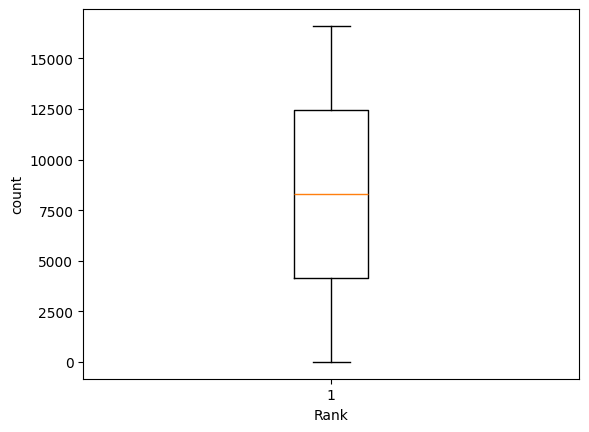

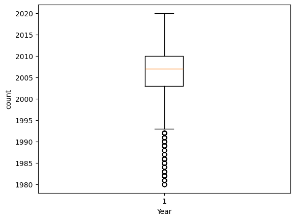

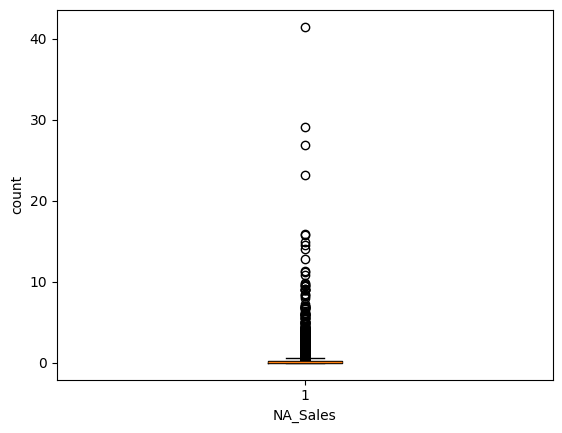

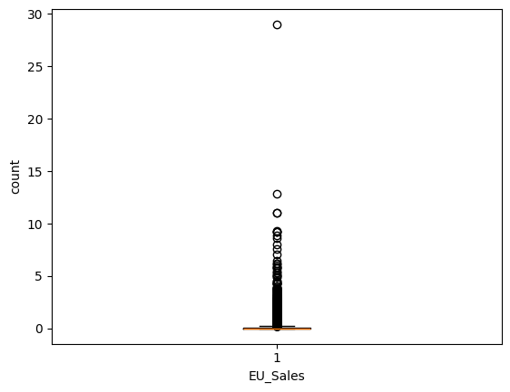

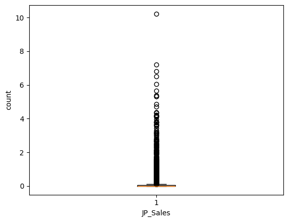

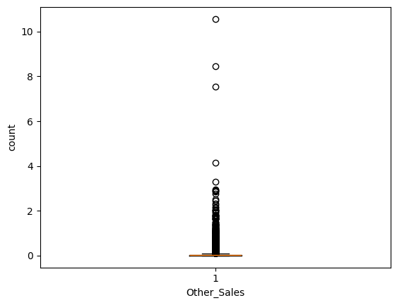

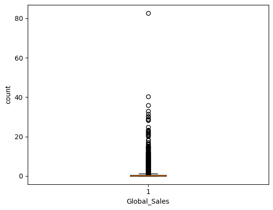

```python
for i in df.columns:
  if df[i].dtype != 'object':
    plt.boxplot(df[i])
    plt.xlabel(i)
    plt.ylabel('count')
    plt.show()
```

**Removal of Outliers** : IQR Method

For one column

```python
Q1 = df['Year'].quantile(0.25)
Q3 = df['Year'].quantile(0.75)

IQR = Q3 - Q1

LF = Q1 - 1.5*IQR
UF = Q3 + 1.5*IQR

df = df[(df['Year'] > LF) & (df['Year'] < UF)]
```

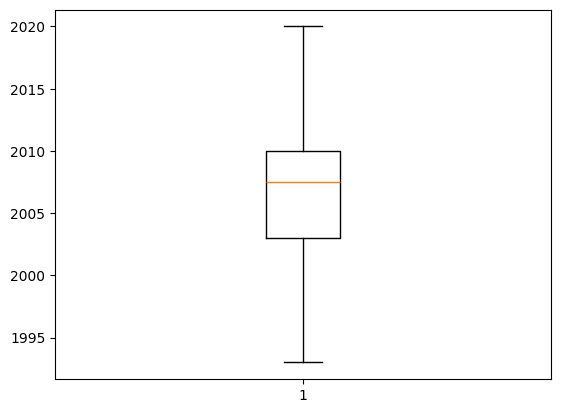

```python
plt.boxplot(df['Year'])
plt.show()
```

For all columns together

```python
col_list = ['NA_Sales','EU_Sales','JP_Sales','Other_Sales','Global_Sales']
```

```python
for i in col_list:
  Q1 = df[i].quantile(0.25)
  Q3 = df[i].quantile(0.75)
  IQR = Q3 - Q1
  LF = Q1 - 1.5*IQR
  UF = Q3 + 1.5*IQR
  df = df[(df[i] > LF) & (df[i] < UF)]
```

to check how data looks after removal of outlier

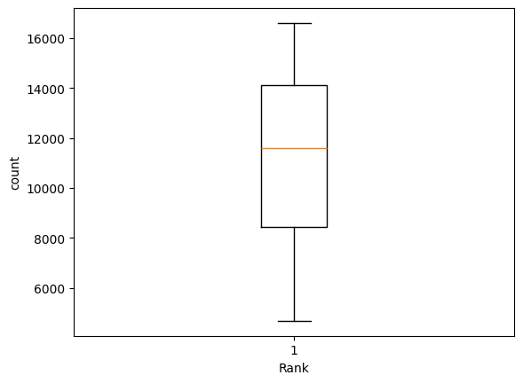

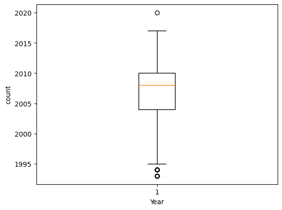

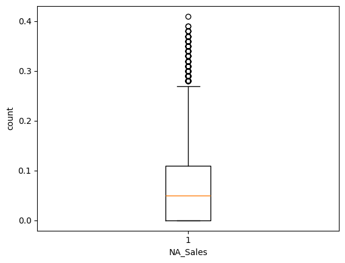

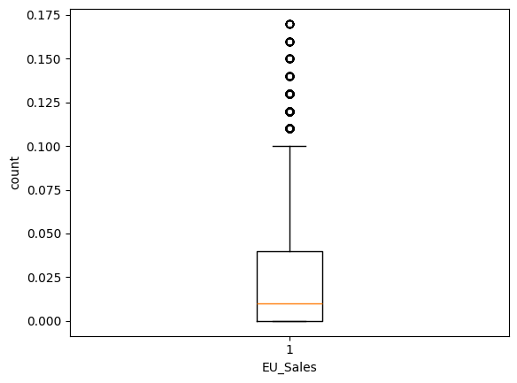

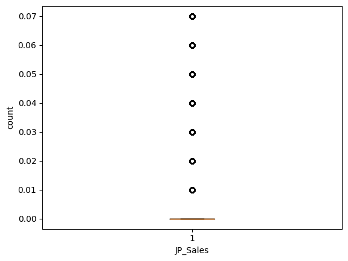

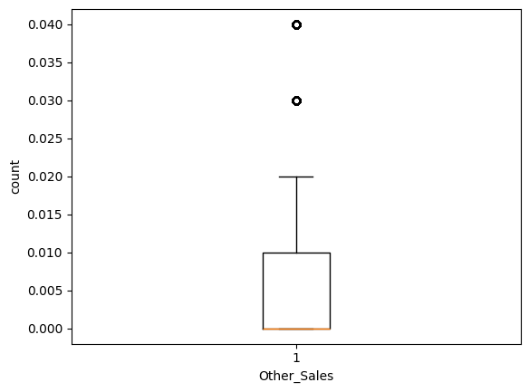

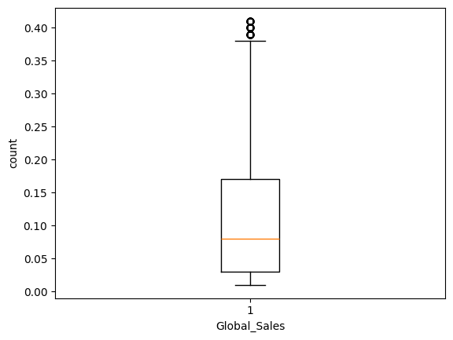

```python
for i in df.columns:
  if df[i].dtype != 'object':
    plt.boxplot(df[i])
    plt.xlabel(i)
    plt.ylabel('count')
    plt.show()
```

```python
df.shape
```

```
(9677, 11)
```

**Let's analyze what values our data holds**

```python
#unique()

#Platform, Year, Genre, Publisher

df['Genre'].unique()
```

```
array(['Shooter', 'Action', 'Adventure', 'Racing', 'Misc', 'Sports',
       'Simulation', 'Platform', 'Strategy', 'Fighting', 'Role-Playing',
       'Puzzle'], dtype=object)
```

```python
df['Genre'].nunique()
```

```
12
```

```python
df['Genre'].value_counts()
```

```
Genre
Action          1899
Sports          1253
Misc            1076
Adventure       1014
Racing           780
Role-Playing     702
Shooter          699
Simulation       530
Platform         467
Strategy         442
Fighting         417
Puzzle           398
Name: count, dtype: int64
```

**Visualization Analysis of Data**

**Q1. What type of video game has been the most popular in terms of production volume?**

```python
top_genre = df['Genre'].value_counts().sort_values(ascending=False)
top_genre.head(3)
```

```
Genre
Action    1899
Sports    1253
Misc      1076
Name: count, dtype: int64
```

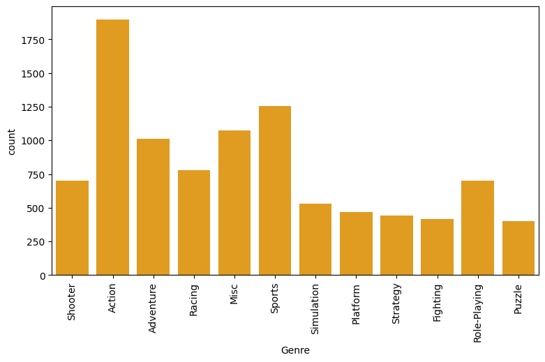

```python
plt.figure(figsize=(9,5))
sns.countplot(x='Genre', data=df, color= 'orange')
plt.xticks(rotation=90)
plt.show()
```

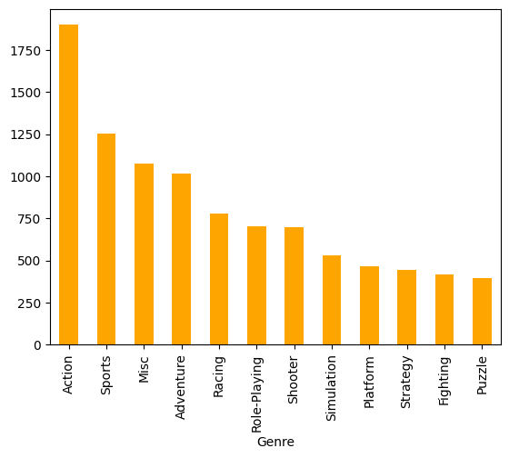

```python
df['Genre'].value_counts().plot(kind='bar', color='orange')
plt.show()
```

**Inference**:

Action and Sports are the two most popular Genres as per production volumns

**Q2. What year witnessed the greatest volume of video game launches?**

Plot for just top 5

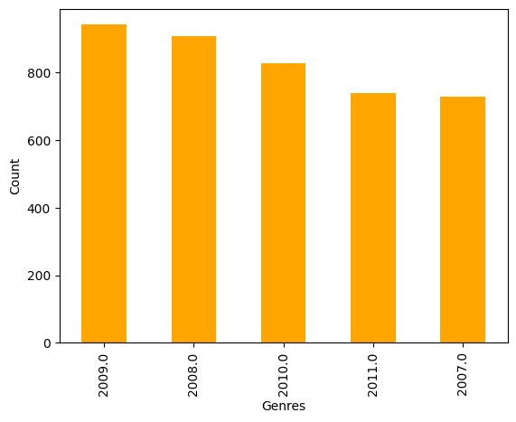

```python
df['Year'].value_counts().head().plot(kind='bar', color='orange')
plt.xlabel('Genres')
plt.ylabel('Count')
```

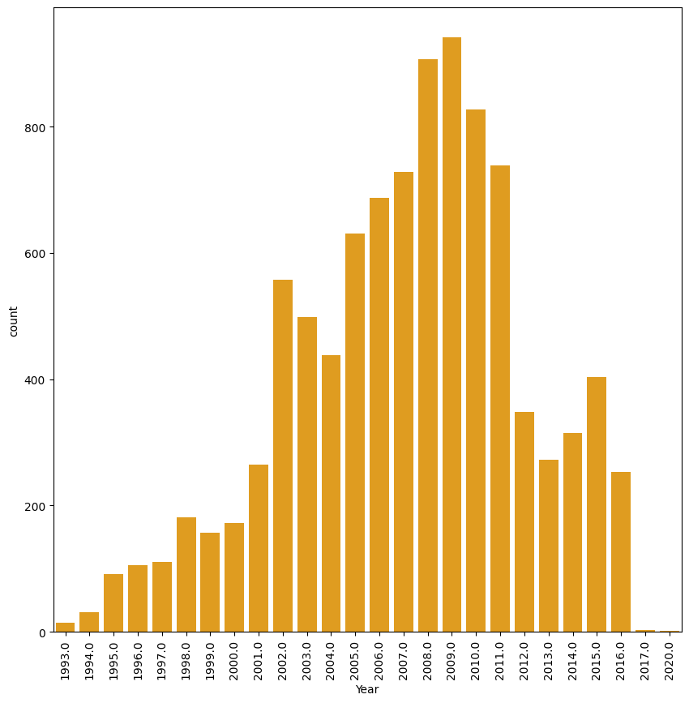

```python
plt.figure(figsize=(10,10))
sns.countplot(x='Year', data=df, color='orange')
plt.xticks(rotation=90)
plt.show()
```

**Q3. What year experienced the most lucrative sales performance on a global scale?**

```python
#year, global_sales

year_sales= df.groupby('Year')['Global_Sales'].sum()
# year_sales
year_sales = year_sales.reset_index()
year_sales
```

|  | Year | Global_Sales |
| --- | --- | --- |
| 0 | 1993.0 | 1.09 |
| 1 | 1994.0 | 1.66 |
| 2 | 1995.0 | 7.46 |
| 3 | 1996.0 | 12.39 |
| 4 | 1997.0 | 16.18 |
| 5 | 1998.0 | 25.14 |
| 6 | 1999.0 | 26.05 |
| 7 | 2000.0 | 27.24 |
| 8 | 2001.0 | 37.16 |
| 9 | 2002.0 | 70.00 |
| 10 | 2003.0 | 64.93 |
| 11 | 2004.0 | 55.76 |
| 12 | 2005.0 | 82.89 |
| 13 | 2006.0 | 65.11 |
| 14 | 2007.0 | 77.09 |
| 15 | 2008.0 | 100.56 |
| 16 | 2009.0 | 108.41 |
| 17 | 2010.0 | 90.41 |
| 18 | 2011.0 | 81.77 |
| 19 | 2012.0 | 32.94 |
| 20 | 2013.0 | 25.20 |
| 21 | 2014.0 | 29.43 |
| 22 | 2015.0 | 29.73 |
| 23 | 2016.0 | 15.04 |
| 24 | 2017.0 | 0.05 |
| 25 | 2020.0 | 0.29 |

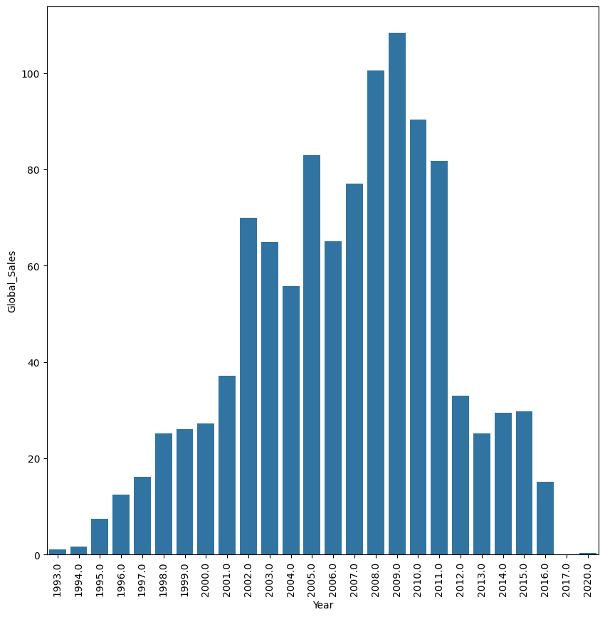

```python
plt.figure(figsize=(10,10))
sns.barplot(x='Year', y='Global_Sales', data=year_sales)
plt.xticks(rotation=90)
plt.show()
```

**Q4. Who are the top publisher of the games in the present dataset. Find the top 20 publishers.**

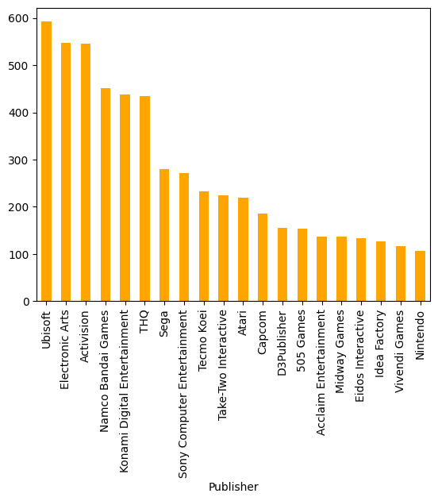

```python
df['Publisher'].value_counts().head(20).plot(kind='bar', color='orange')
```